# Proyecto Estadistica. Grupo6

Alejandro Donoso, Carlos Gómez, Joan Gutiérrez, Luis Guaillas

16/1/2022

Ingreso de datos y uso de librerias

```r
library(readxl)
library(agricolae)
library(BSDA)
```

```r
library(corrplot)
library(psych)

datos_estudiantes <- read_excel("datos_estudiantes.xlsx")
```

Capitulo 1

1.Objetivos

1.1.Objetivo General

- Analizar la relacion entre la alimentacion y el indice de episodios emocionales sufridos por los Estudiantes de Estadistica de los Paralelos 2 y 5.

1.2.Objetivo Especifico

- Demostrar la Relacion de Causa-Efecto entre los episodios de Ansiedad y el bajo consumo de agua por parte de los estudiantes.
- Medir el porcentaje de Carbohidratos y gaseosas consumidos por los estudiantes, y la relacion con su estado emocional.
- Comparar el indice IMC de los estudiantes con los episodios de tristeza, como indicador de que la forma del cuerpo influye en la felicidad de los estudiantes

2.Introducción

Muchas veces hemos escuchado cosas como bebe agua para calmar los nervios y la ansiedad, incluso existe un dicho en mexico que dice “un bolillo, para es susto”. de tal forma parece ser que la alimenticion tiene relacion con lo emocional, una explicacion cientifica a esto pueden ser las hormonas y los neurotransmisores, quienes son los mensajeros químicos del cuerpo, y viajan a través del torrente sanguíneo hacia los tejidos y órganos, incluyendo el cerebro, a traves de Neurotransmisores positivos como la serotonina, la dopamina o las endorfinas. Será entonces el aumento o descenso de estas sustancias así como la presencia o ausencia de otras negativas, como la adrenalina o el cortisol, provocará en nosotros que nos sintamos más optimistas, motivados, animados o que por el contrario nos desanimemos, o tengamos una sensación de tristeza inexplicable. entre las mencionadas anteriormente tenemos: - La serotonina, que modula el estado de ánimo así como las emociones, el sueño y el apetito. Clave para nuestra felicidad y ayuda a combatir el estrés y la depresión. Para que se produzca serotonina en nuestro cerebro es necesaria la presencia del triptófano. - La dopamina controla el movimiento, emociones, los ciclos de sueño y la capacidad de experimentar placer. Nos hace sentirnos bien y es determinante para mantener nuestros niveles de energía y favorece la concentración y motivación - Las endorfinas, opiáceos naturales del organismo con un poder mayor que cualquier medicamento contra el dolor. Promueven estados de bienestar, calma, mejoran el humor, contrarrestan los niveles elevados de adrenalina asociados a la ansiedad, potencian las funciones del sistema inmunitario y ayudan a reducir el dolor. Sustancias imprescindibles para nuestro organismo y directamente relacionadas con nuestro ánimo sería el grupo de vitaminas B siendo de importancia para el estado de animo, especialmente la vitamina B12 que aumenta la concentracion, la fibra que libera glucosa en el flujo sanguíneo de forma gradual, evitando que baje el azúcar ayudando en el humor, algunos ácidos grasos como el omega3 que favorece la disminución de síntomas de ansiedad, trastornos del sueño, sentimientos de tristeza; el triptófano imprescindible para la fabricación de serotonina, y minerales como el zinc que se relacionan con trastornos de estado de ánimo que además es una gran fuente de energía. Asi tambien tenemossustancias que deberian consumirse con moderacio por us efecto en el cuerpo como el azucar que en exceso puede generar fluctuaciones de azúcar en la sangre, que pueden provocar cambios de humor, y ejercer un efecto dañino sobe nuestra salud mental; las grasas saturadas cuyo consumo elevado causa engrosamiento de los vasos sanguíneos y bajan los niveles de serotonina, llevando a sentimientos de tristeza y desánimo, además de una desagradable sensación de pesadez y la Cafeina, que con su consumo excesivo puede producir irritabilidad, problemas estomacales, disminuir el ritmo cardíaco y además insomnio. Con respecto a la relacion Agua-Ansiedad, en un estudio de 2018 con más de 3,000 adultos, los que tomaron más agua tuvieron un menor riesgo de ansiedad y depresión que los que tomaron menos agua, Aunque la conexión entre la deshidratación y la depresión era más fuerte, los investigadores encontraron que la ansiedad era más alta en aquellos que no bebían suficiente agua, de igual manera, Un estudio más pequeño de 2014, donde los investigadores exploraron cómo aumentar o reducir el consumo de agua afectaba el estado de ánimo en las personas con diferentes hábitos para tomarla, Hallaron que las personas que usualmente tomaban mucha agua se sentían menos calmadas, menos contentas y más tensas cuando reducían su consumo de agua, Cuando los investigadores aumentaron el consumo de agua en los participantes, las personas en el estudio sentían más felicidad, sin importar cuánta agua tomaban normalmente, con los casos mencionados anteriormente, ademas de la duda acerca de la relacion del aspecto fisico con el estado de animo, nos llevo a realizar la siguientes pruebas para encontrar las respuestas a nuestras preguntas planteadas

Capitulo 2

Capitulo 3

Capitulo 4

4.Analisis Conjunto (Diagramas de cajas con cuant. y cualit)

4.1. Diagrama de cajas de consumo promedio semanal de agua segmentado por Episodios por semana de Ansiedad

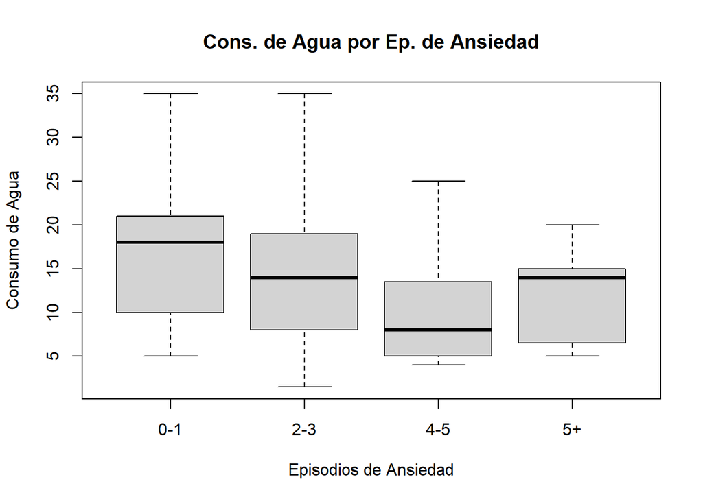

```r
boxplot(datos_estudiantes$Consumo_promedio_semanal_agua~
          datos_estudiantes$Episodios_por_semana_ansiedad,
        ylab = 'Consumo de Agua', xlab = 'Episodios de Ansiedad',
        names= c("0-1","2-3","4-5","5+"),
        main='Cons. de Agua por Ep. de Ansiedad'
)
```

Se puede observar en el grafico que la mediana de consumo semanal de agua de las personas que han tenido hasta 1 episodio de ansiedad es mayor en comparación a las personas que tienen mas de 2 episodios semanales de ansiedad. También se puede destacar que el 3er cuartil de las personas que sufren hasta 1 episodio de ansiedad es superior en comparación al 3er cuartil de las personas que sufren mas de 2 episodios de ansiedad. Por el momento se puede concluir que las personas que consumen más agua tienen menos episodios de ansiedad

4.2. Diagrama de cajas de consumo promedio semanal de gaseosa segmentado por Episodios por semana de Ansiedad

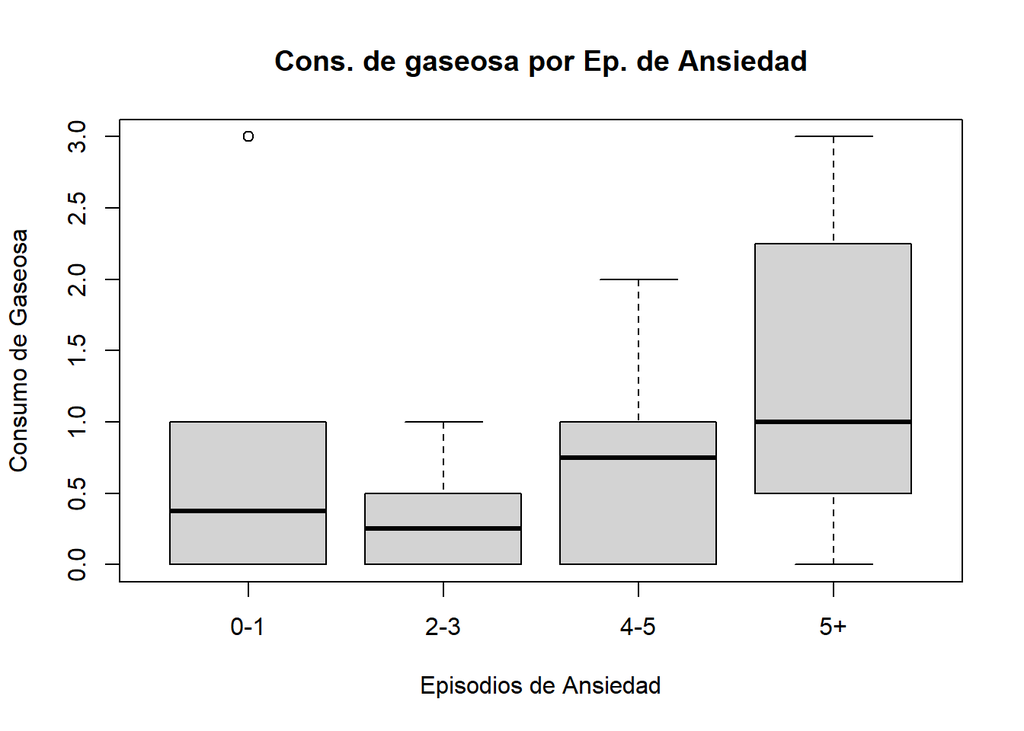

```r
boxplot(datos_estudiantes$Consumo_semanal_promedio_gaseosas~
          datos_estudiantes$Episodios_por_semana_ansiedad,
        ylab = 'Consumo de Gaseosa', xlab = 'Episodios de Ansiedad',
        names= c("0-1","2-3","4-5","5+"),
        main='Cons. de gaseosa por Ep. de Ansiedad'
)
```

Se puede observar que la mediana de las personas que tienen de 4 a 5 episodios o mas son superiores en comparación a las personas que tienen entre 2 o 3 episodios o incluso de los que tienen hasta 1 episodio de ansiedad. Pero se puede observar que la mediana de las personas que sufren de 2 a 3 episodios es menor en comparación a las personas que sufren hasta 1 episodio. Entonces esto no indicaría que a mayor consumo de gaseosas se puede tener más episodios de ansiedad.

4.3. Diagrama de cajas de porcentaje promedio de carbohidrato por comida segmentado por Episodios por semana de Ira o Frustración

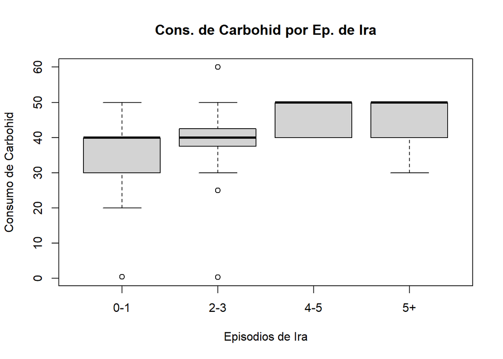

```r
boxplot(datos_estudiantes$Porcentaje_promedio_carbohidrato_por_comida~
          datos_estudiantes$Episodios_por_semana_ira_frustacion,
        ylab = 'Consumo de Carbohid', xlab = 'Episodios de Ira',
        names= c("0-1","2-3","4-5","5+"),
        main='Cons. de Carbohid por Ep. de Ira'
)
```

En este grafico se puede observar que las medianas de las personas que sufren de 4 a más episodios de ira esta alrededor de 50 en cuanto al porcentaje promedio de consumo de carbohidrato y a su vez se observa que es mayor en comparación a las medianas de las personas que tienen menos de 4 episodios de ira. Pero también se observan que la distribución es muy asimétrica. Por el momento se puede concluir que las personas que consumen un mayor porcentaje promedio de carbohidratos suelen tener más episodios de ira.

4.4. Diagrama de cajas IMC segmentado por Episodios por semana de Tristeza

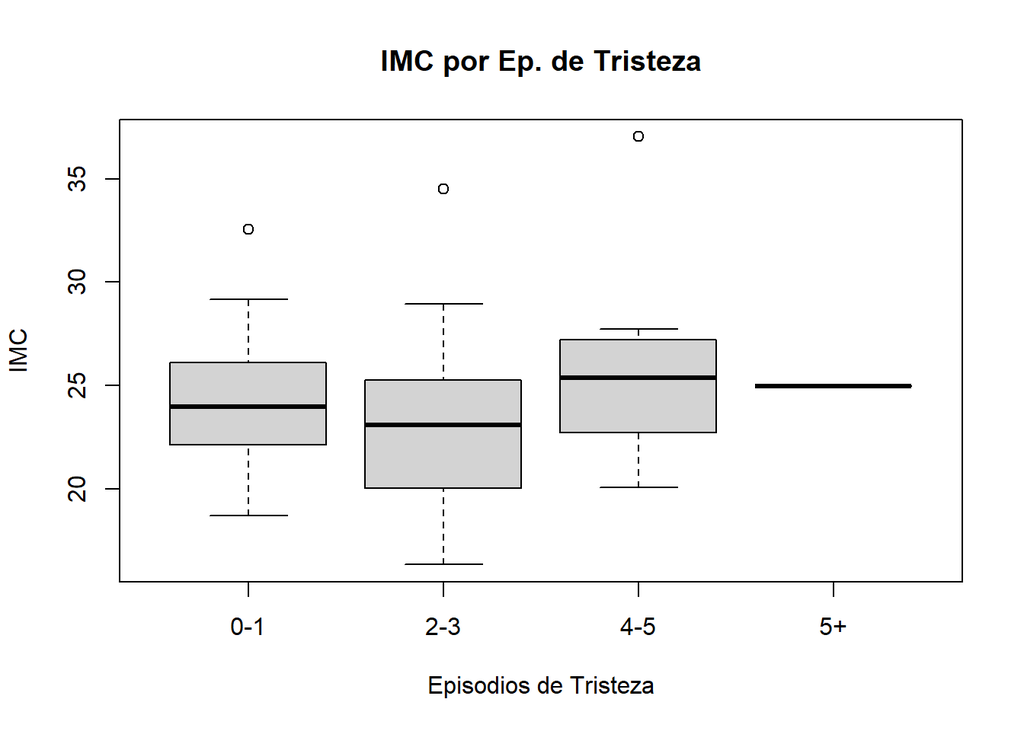

```r
imc = (datos_estudiantes$Peso/2.2)/(datos_estudiantes$Estatura**2)
datos_estudiantes$IMC = imc

boxplot(datos_estudiantes$IMC~
          datos_estudiantes$Episodios_por_semana_tristeza,
        ylab = 'IMC', xlab = 'Episodios de Tristeza',
        names= c("0-1","2-3","4-5","5+"),
        main='IMC por Ep. de Tristeza'
)
```

Al observar el grafico vemos que las medianas del índice de masa corporal (IMC) entre las personas que tienen un determinado numero de episodios de tristeza son muy inconsistentes, lo mas relevante que se puede decir es que las personas que tienen entre 4 a 5 episodios tienen una mediana superior en comparación al resto. Entonces esto no indicaría que a mayor índice de masa corporal hay mayores episodios de tristeza.

4.5. Diagrama de cajas de consumo promedio semanal de agua segmentado por Episodios por semana de Estres

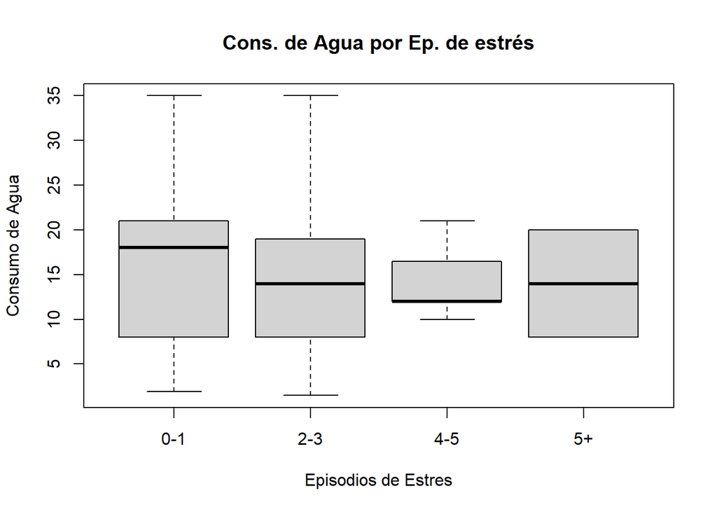

```r
boxplot(datos_estudiantes$Consumo_promedio_semanal_agua~
          datos_estudiantes$Episodios_por_semana_estres,
        ylab = 'Consumo de Agua', xlab = 'Episodios de Estres',
        names= c("0-1","2-3","4-5","5+"),
        main='Cons. de Agua por Ep. de estrés'
)
```

Al observar el grafico, vemos que la mediana de las personas que tienen hasta un episodio de estrés es superior en comparación al resto es superior e incluso esta mas cercana al 3er cuartil por lo que se puede decir que las personas que consumen mas agua tienen hasta 1 episodio de estrés.

4.6. Diagrama de cajas de porcentaje promedio de carbohidrato por comida segmentado por Episodios por semana de Miedo

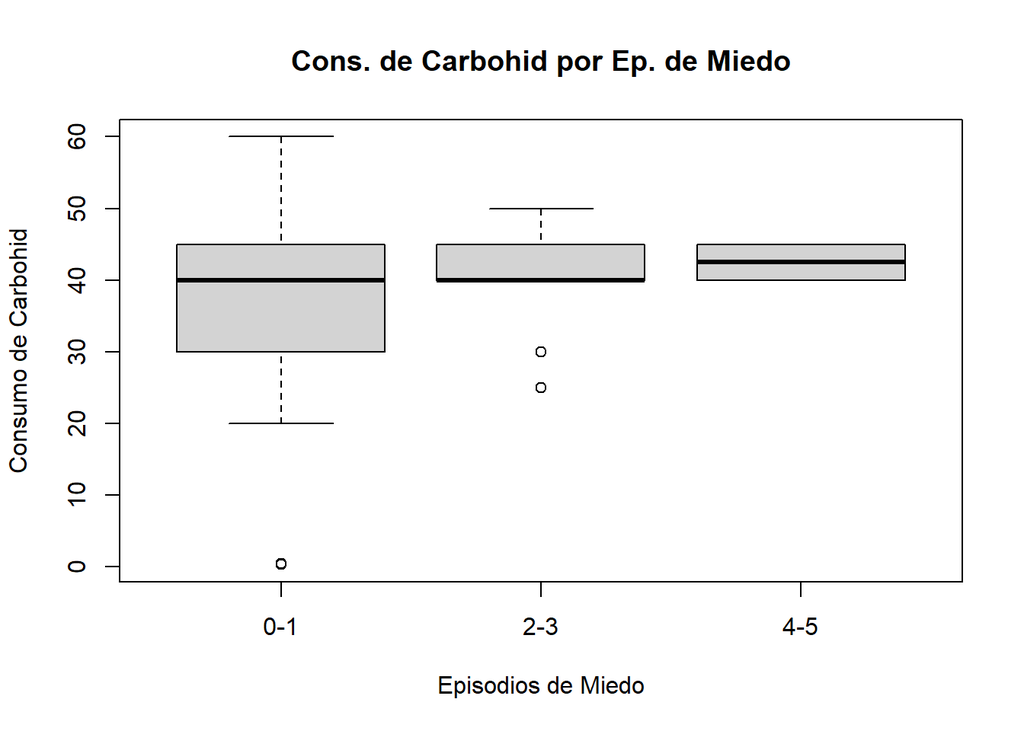

```r
boxplot(datos_estudiantes$Porcentaje_promedio_carbohidrato_por_comida~
          datos_estudiantes$Episodios_por_semana_miedo,
        ylab = 'Consumo de Carbohid', xlab = 'Episodios de Miedo',
        names=c("0-1","2-3","4-5"),
        main='Cons. de Carbohid por Ep. de Miedo'
)
```

Al observar este grafico vemos que las medianas del consumo de carbohidratos de las personas que tienen ente 0-1 o 2-3 están muy cercanas entre si aproximadamente por el 40% de carbohidrato por comida, pero se observa que las personas que tienen de 4 - 5 episodios su mediana es más alta que el resto. Entonces se podría decir por el momento que las personas que consumen más carbohidratos por comida tienden a tener más episodios de miedo.

Capitulo 5

5.Análisis covarianza y correlación

```r
imc = (datos_estudiantes$Peso/2.2)/(datos_estudiantes$Estatura**2)
datos_estudiantes$IMC = imc
datos_cuantitativos = datos_estudiantes[,c(5,6,16,18,20,38)]
names(datos_cuantitativos) = c('Peso', 'Est', 'Prom.Gaseos',
                               'Prom.Agua', 'Prom.Carb.Comida', 'IMC')

matriz_cov = round(cov(na.omit(datos_cuantitativos)),2)
matriz_cov
```

```
##                    Peso  Est Prom.Gaseos Prom.Agua Prom.Carb.Comida   IMC
## Peso             865.43 1.55        6.46     46.66             4.32 94.78
## Est                1.55 0.01        0.01      0.25             0.00  0.00
## Prom.Gaseos        6.46 0.01        0.71     -0.85             0.17  0.76
## Prom.Agua         46.66 0.25       -0.85     57.14            -2.01  0.84
## Prom.Carb.Comida   4.32 0.00        0.17     -2.01           130.47  0.49
## IMC               94.78 0.00        0.76      0.84             0.49 15.53
```

```r
matriz_corr = round(cor(na.omit(datos_cuantitativos)), 2)
matriz_corr
```

```
##                  Peso  Est Prom.Gaseos Prom.Agua Prom.Carb.Comida  IMC
## Peso             1.00 0.57        0.26      0.21             0.01 0.82
## Est              0.57 1.00        0.14      0.36             0.00 0.00
## Prom.Gaseos      0.26 0.14        1.00     -0.13             0.02 0.23
## Prom.Agua        0.21 0.36       -0.13      1.00            -0.02 0.03
## Prom.Carb.Comida 0.01 0.00        0.02     -0.02             1.00 0.01
## IMC              0.82 0.00        0.23      0.03             0.01 1.00
```

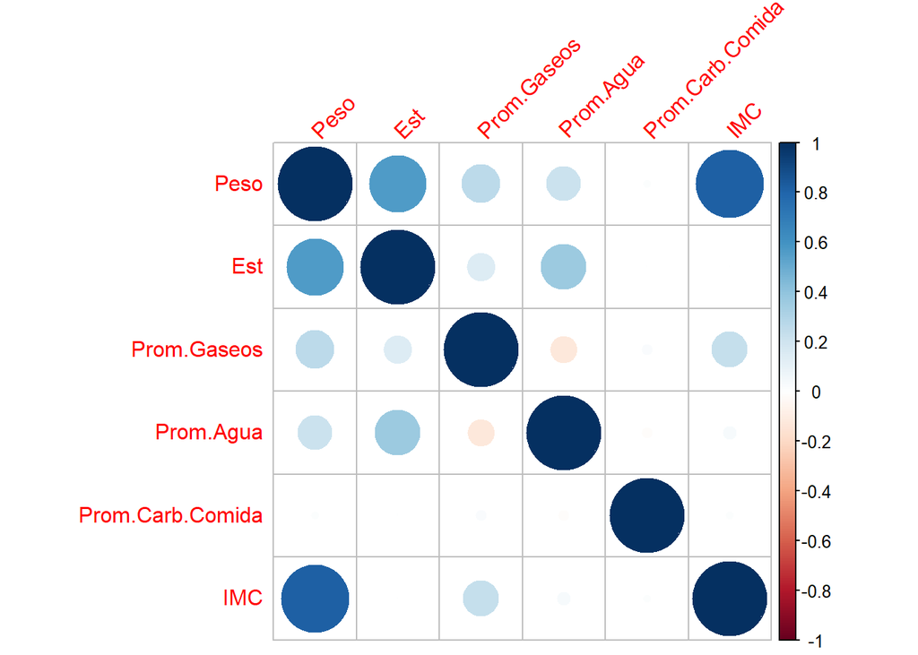

```r
corrplot(matriz_corr, method="circle", tl.srt=45)
```

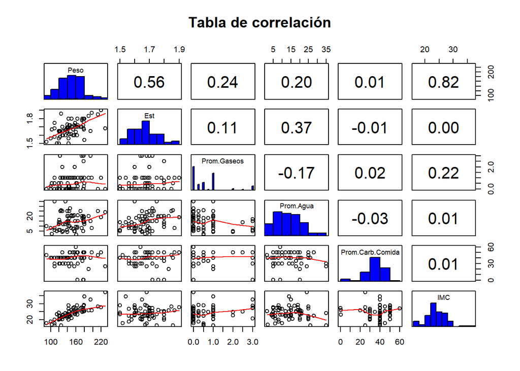

```r
pairs.panels(datos_cuantitativos,

             density = FALSE,

             ellipses = FALSE,

             pch = 21,

             main = "Tabla de correlación",

             hist.col = "blue")
```

En la gráfica podemos ver como aquellos valores de correlación negativa y positivo muestran datos próximos entre sí y que las rectas de regresión tienen una pendiente negativa y positiva, respectivamente. Mientras que en los casos donde el coeficiente de correlación es cercano a 0 se muestran datos más dispersos y no se puede formar bien una línea recta de regresión.

Capitulo 6

6.Análisis Intervalos de Confianza

- Para las siguientes variables se calculará los intervalos de confianza, con un nivel de 95% de confianza.
- Se obtendrán muestras aleatorias de tamaño 30.

Codigo para calcular los Intervalos de Confianza

```r
intervaloConfianza <- function (muestra, nivelConfianza, z = T) {

  estadistico = 0

  media = mean(muestra, na.rm = T)

  significancia = (1 - (nivelConfianza/100))/2

  errorEstandar = sd(muestra, na.rm = T) / sqrt(length(muestra))



  if(z) {

    estadistico = qnorm(significancia, lower.tail = F) }

  else {

    estadistico = qt(significancia, lower.tail = F, length(muestra) - 1) }



  c(media - (estadistico * errorEstandar), media + (estadistico * errorEstandar))

}
```

6.1.Consumo semanal promedio de gaseosas

```r
set.seed(1)
muestra_gaseosas = sample(datos_estudiantes$Consumo_semanal_promedio_gaseosas,

                          size=30, replace = F)

media_gaseosas = mean(muestra_gaseosas, na.rm = T)

media_gaseosas
```

```
## [1] 0.6465517
```

```r
int_confianza_gaseosas = intervaloConfianza(muestra_gaseosas, 95, T)

int_confianza_gaseosas
```

```
## [1] 0.3512793 0.9418242
```

**Conclusión**

El consumo semanal promedio de gaseosas, de las personas del estudio esta entre 0.3512793 y 0.9418242 litros con un nivel de confianza de 95%.

```r
set.seed(1)
muestra_agua = sample(datos_estudiantes$Consumo_promedio_semanal_agua,

                          size=30, replace = F)

media_agua = mean(muestra_agua, na.rm = T)

media_agua
```

```
## [1] 14.78
```

```r
int_confianza_agua = intervaloConfianza(muestra_agua, 95, T)

int_confianza_agua
```

```
## [1] 12.10349 17.45651
```

6.3.Consumo promedio semanal de agua

```r
set.seed(1)
muestra_agua = sample(datos_estudiantes$Consumo_promedio_semanal_agua,
                          size=30, replace = F)

media_agua = mean(muestra_agua, na.rm = T)
media_agua
```

```
## [1] 14.78
```

```r
int_confianza_agua = intervaloConfianza(muestra_agua, 95, T)
int_confianza_agua
```

```
## [1] 12.10349 17.45651
```

6.4.IMC

```r
imc = (datos_estudiantes$Peso/2.2)/(datos_estudiantes$Estatura**2)
datos_estudiantes$IMC = imc
set.seed(1)
muestra_imc = sample(datos_estudiantes$IMC,
                      size=30, replace = F)
media_imc = mean(muestra_imc, na.rm = T)
media_imc
```

```
## [1] 24.08149
```

```r
int_confianza_imc = intervaloConfianza(muestra_imc, 95, T)
int_confianza_imc
```

```
## [1] 22.79596 25.36702
```

**Conclusión**

El índice de masa corporal, de las personas del estudio esta entre los valores 22.79596 y 25.36702 con un nivel de confianza de 95%.

Capitulo 7

7.Analisis de Prueba de Hipotesis

Codigo para la prueba de hipotesis de diferencia de medias

```r
tprueba2=function(me1,me2, difH0,var1,var2,n1, n2,tipo){
  varc=((n1-1)*var1+(n2-1)*var2)/(n1+n2-2)
  z=((me1-me2)-difH0)/sqrt(varc*(1/n1+1/n2))
  if(tipo=="mayor"){
    p=pt(z,n1+n2-2,lower.tail=FALSE)
  }
  if(tipo=="menor"){
    p=pt(z,n1+n2-2,lower.tail=TRUE)
  }
  if(tipo=="diferente"){
    p=min((2*pt(z,n1+n2-2,lower.tail=FALSE)),(2*pt(z,n-1,lower.tail=TRUE)))
  }
  return(p)
}
```

7.1.Consumo Promedio semanal de agua por episodios de ansiedad

7.1.1Condiciones

- La variable de consumo promedio semanal de agua proviene de una distribución normal.
- El nivel de significancia para la prueba de hipótesis es de 5%.
- Se selecciono 2 muestras aleatorias ambas de tamaño 20.

7.1.2 Planteamiento de la hipótesis

- 1era muestra: Una muestra de 20 personas que tienen hasta 1 episodio de ansiedad por semana.
- 2da muestra: Una muestra de 20 personas que tienen más de 2 episodios de ansiedad por semana.

-Hipótesis-

- H0: media del consumo promedio semanal de agua de las personas que sufren hasta 1 episodio de ansiedad es menor o igual a la media de consumo promedio semanal de agua de las personas que tienen mas de 2 episodios de ansiedad
- H1: media del consumo promedio semanal de agua de las personas que sufren hasta 1 episodio de ansiedad es mayor a la media de consumo promedio semanal de agua de las personas que tienen más de 2 episodios de ansiedad

```r
#Agua con Ansiedad
#A 95% nivel de confianza
#Diferencia de prom de consumo agua
set.seed(3)
ep_ansiedad = datos_estudiantes$Episodios_por_semana_ansiedad
#Muestra personas con 0-1 ep. ansiedad
muestra_agua1 = sample(datos_estudiantes$Consumo_promedio_semanal_agua
                       [ep_ansiedad==1], size = 20, replace = F)
media_muestra_agua1 = median(muestra_agua1, na.rm = T)
var_muestra1 = var(muestra_agua1, na.rm = T)
n_muestra1 = length(muestra_agua1)
#Muestra personas con mas de 2 ep. ansiedad
muestra_agua2 = sample(datos_estudiantes$Consumo_promedio_semanal_agua
                       [ep_ansiedad!=1], size = 20, replace = F)
media_muestra_agua2 = median(muestra_agua2, na.rm = T)
var_muestra2 = var(muestra_agua2, na.rm = T)
n_muestra2 = length(muestra_agua1)
valor_p = tprueba2(media_muestra_agua1, media_muestra_agua2,
            0, var_muestra1, var_muestra2, n_muestra1, n_muestra2, 'mayor')
valor_p
```

```
## [1] 0.01065632
```

**Resultados:**

Debido a que el valor de p es menor que al nivel de significancia se rechaza la hipótesis nula. Concluyendo que las personas que tienen hasta 1 episodio de ansiedad tienen un consumo promedio de agua mayor de las que tienen más de 2 episodios.

7.2 Consumo Promedio semanal de gaseosa por episodios de ansiedad

7.2.1 Condiciones

- La variable de consumo promedio semanal de gaseosa proviene de una distribución normal.
- El nivel de significancia para la prueba de hipótesis es de 5%.
- Se selecciono 2 muestras aleatorias ambas de tamaño 20.

7.2.2 Planteamiento de la hipótesis

- 1era muestra: Una muestra de 20 personas que tienen hasta 3 episodios de ansiedad por semana.
- 2da muestra: Una muestra de 20 personas que tienen más de 4 episodios de ansiedad por semana.

-Hipótesis-

- H0: media del consumo de gaseosas de las personas que sufren hasta 3 episodio de ansiedad es mayor o igual a la media de gaseosas de las personas que tienen más de 4 episodios de ansiedad.
- H1: media del consumo de gaseosas de las personas que sufren hasta 3 episodio de ansiedad es menor que la media de gaseosas de las personas que tienen más de 4 episodios de ansiedad.

```r
#Gaseosa con Ansiedad
#A 95% nivel de confianza
#Diferencia de prom de consumo gaseosas
set.seed(3)
ep_ansiedad = datos_estudiantes$Episodios_por_semana_ansiedad
#Muestra personas con 0-3 ep. ansiedad
muestra_gaseosa1 = sample(datos_estudiantes$Consumo_semanal_promedio_gaseosas
                          [ep_ansiedad<=2], size = 20, replace = F)
media_muest_gaseosa1 = median(muestra_gaseosa1, na.rm = T)
var_muestra1 = var(muestra_gaseosa1, na.rm = T)
n_muestra1 = length(muestra_gaseosa1)
#Muestra personas con mas de 4 ep. ansiedad
muestra_gaseosa2 = sample(datos_estudiantes$Consumo_semanal_promedio_gaseosas
                          [ep_ansiedad>2], size = 20, replace = F)
media_muest_gaseosa2 = median(muestra_gaseosa2, na.rm = T)
var_muestra2 = var(muestra_gaseosa2, na.rm = T)
n_muestra2 = length(muestra_gaseosa2)
valor_p = tprueba2(media_muest_gaseosa1, media_muest_gaseosa2,
                   0, var_muestra1, var_muestra2, n_muestra1, n_muestra2, 'menor')
valor_p
```

```
## [1] 0.01019676
```

**Resultados:**

Debido a que el valor de p es menor que al nivel de significancia se rechaza la hipótesis nula en favor de la alterna. Concluyendo que las personas que tienen hasta 3 episodio de ansiedad tienen un consumo promedio de gaseosas menor que las que tienen más de 4 episodios de ansiedad.

7.3 Porcentaje de Carbohidratos por episodios de ira

7.3.1 Condiciones

- La variable de Porcentaje de Carbohidratos por comida proviene de una distribución normal.
- El nivel de significancia para la prueba de hipótesis es de 5%.
- Se selecciono 2 muestras aleatorias ambas de tamaño 20.

7.3.2 Planteamiento de la hipótesis

-Hipótesis-

- H0: media del porcentaje de consumo de carbohidratos de las personas que tienen 1 episodio de ira es mayor o igual a la media del porcentaje de consumo de carbohidratos de las personas que tienen 2 o más episodios de ira.
- H1: media del porcentaje de consumo de carbohidratos de las personas que tienen 1 episodio de ira es menor a la media del porcentaje de consumo de carbohidratos de las personas que tienen 2 o más episodios de ira.

```r
#Carbohidratos por Ira
#A 95% nivel de confianza
#Diferencia de prom de consumo carbohid
set.seed(3)
ep_ira = datos_estudiantes$Episodios_por_semana_ira_frustacion
#Muestra personas con 0-1 ep. ira
muestra_ira1 = sample(datos_estudiantes$Porcentaje_promedio_carbohidrato_por_comida
                          [ep_ira==1], size = 20, replace = F)
media_muest_ira1 = median(muestra_ira1, na.rm = T)
var_muestra1 = var(muestra_ira1, na.rm = T)
n_muestra1 = length(muestra_ira1)
#Muestra personas con mas de 2 ep. de ira
muestra_ira2 = sample(datos_estudiantes$Porcentaje_promedio_carbohidrato_por_comida
                          [ep_ira>1], size = 20, replace = F)
media_muest_ira2 = median(muestra_ira2, na.rm = T)
var_muestra2 = var(muestra_ira2, na.rm = T)
n_muestra2 = length(muestra_ira2)
valor_p = tprueba2(media_muest_ira1, media_muest_ira2,
                   0, var_muestra1, var_muestra2, n_muestra1, n_muestra2, 'menor')
valor_p
```

```
## [1] 0.5
```

**Resultados:**

Debido a que el valor de p es mayor que el nivel de significancia se acepta la hipótesis nula. Concluyendo que las personas que tienen 1 episodio de ira tienen un consumo de carbohidratos mayor o igual que las personas que tienen 2 o más episodios de ira.

7.4 IMC por episodios de tristeza

7.4.1 Condiciones

- La variable de índice de masa corporal (IMC) proviene de una distribución normal.
- El nivel de significancia para la prueba de hipótesis es de 5%.
- Se selecciono 2 muestras aleatorias ambas de tamaño 20.

7.4.2 Planteamiento de la hipótesis

- 1era muestra: Una muestra de 20 personas que tienen más de 2 episodios de tristeza por semana.
- 2da muestra: Una muestra de 20 personas que tienen hasta 1 episodio de tristeza por semana.

-Hipótesis-

- H0: media del IMC de las personas que tienen mas de 2 episodios de tristeza es menor o igual a la media del IMC de las personas que tienen hasta 1 episodio de tristeza.
- H1: media del IMC de las personas que tienen más de 2 episodios de tristeza es mayor a la media del IMC de las personas que tienen hasta 1 episodio de tristeza.

```r
#IMC por tristeza
#A 95% nivel de confianza
imc = (datos_estudiantes$Peso/2.2)/(datos_estudiantes$Estatura**2)
datos_estudiantes$IMC = imc
#Diferencia de IMC
set.seed(3)
ep_tristeza = datos_estudiantes$Episodios_por_semana_tristeza
#Muestra personas con mas de 2 ep tristeza
muestra_tristeza1 = sample(datos_estudiantes$IMC
                      [ep_tristeza>=2], size = 20, replace = F)
media_muest_tristeza1 = median(muestra_tristeza1, na.rm = T)
var_muestra1 = var(muestra_tristeza1, na.rm = T)
n_muestra1 = length(muestra_tristeza1)
#Muestra personas con 0-1 ep tristeza
muestra_tristeza2 = sample(datos_estudiantes$IMC
                           [ep_tristeza<2], size = 20, replace = F)
media_muest_tristeza2 = median(muestra_tristeza2, na.rm = T)
var_muestra2 = var(muestra_tristeza2, na.rm = T)
n_muestra2 = length(muestra_tristeza2)
valor_p = tprueba2(media_muest_tristeza1, media_muest_tristeza2,
                   0, var_muestra1, var_muestra2, n_muestra1, n_muestra2, 'mayor')
valor_p
```

```
## [1] 0.6551908
```

7.5 Consumo Promedio semanal de agua por episodios de estrés

7.5.1 Condiciones

- La variable de consumo promedio semanal de agua proviene de una distribución normal.
- El nivel de significancia para la prueba de hipótesis es de 5%.
- Se selecciono 2 muestras aleatorias ambas de tamaño 20.

7.5.2 Planteamiento de la hipótesis

- 1era muestra: Una muestra de 20 personas que tienen hasta 1 episodio de estrés por semana.
- 2da muestra: Una muestra de 20 personas que tienen más de 2 episodios de estrés por semana.

-Hipótesis-

- H0: media del consumo promedio semanal de agua de las personas que sufren hasta 1 episodio de estrés es menor o igual a la media de consumo promedio semanal de agua de las personas que tienen más de 2 episodios de estrés.
- H1: media del consumo promedio semanal de agua de las personas que sufren hasta 1 episodio de estrés es mayor a la media de consumo promedio semanal de agua de las personas que tienen más de 2 episodios de estrés.

```r
#Agua por Estres
#A 95% nivel de confianza
#Diferencia de agua
set.seed(3)
ep_estres = datos_estudiantes$Episodios_por_semana_estres
#Muestra personas con 0-1 ep estres
muestra_estres1 = sample(datos_estudiantes$Consumo_promedio_semanal_agua

                           [ep_estres==1], size = 20, replace = F)
media_muest_estres1 = median(muestra_estres1, na.rm = T)
var_muestra1 = var(muestra_estres1, na.rm = T)
n_muestra1 = length(muestra_estres1)
#Muestra personas con mas de 2 ep estres
muestra_estres2 = sample(datos_estudiantes$Consumo_promedio_semanal_agua

                         [ep_estres!=1], size = 20, replace = F)
media_muest_estres2 = median(muestra_estres2, na.rm = T)
var_muestra2 = var(muestra_estres2, na.rm = T)
n_muestra2 = length(muestra_estres2)
valor_p = tprueba2(media_muest_estres1, media_muest_estres2,
                   0, var_muestra1, var_muestra2, n_muestra1, n_muestra2, 'mayor')
valor_p
```

```
## [1] 0.00551715
```

**Resultados:**

Debido a que el valor de p es menor que al nivel de significancia se rechaza la hipótesis nula. Concluyendo que las personas que tienen hasta 1 episodio de estrés tienen un consumo promedio de agua mayor de las que tienen más de 2 episodios de estrés.

7.6 Porcentaje de Carbohidratos por episodios de miedo

7.6.1 Condiciones

- La variable de Porcentaje de Carbohidratos por comida proviene de una distribución normal.
- El nivel de significancia para la prueba de hipótesis es de 5%.
- Se selecciono 2 muestras aleatorias ambas de tamaño 20.

7.6.2 Planteamiento de la hipótesis

- 1era muestra: Una muestra de 20 personas que tienen hasta 1 episodio de miedo por semana.
- 2da muestra: Una muestra de 20 personas que tienen 2 o más episodios de miedo por semana.

-Hipótesis-

- H0: media del porcentaje de consumo de carbohidratos de las personas que tienen 1 episodio de miedo es mayor o igual a la media del porcentaje de consumo de carbohidratos de las personas que tienen 2 o más episodios de miedo.
- H1: media del porcentaje de consumo de carbohidratos de las personas que tienen 1 episodio de miedo es menor a la media del porcentaje de consumo de carbohidratos de las personas que tienen 2 o más episodios de miedo.

```r
#Carbohidratos por Miedo
#A 95% nivel de confianza
#Diferencia de carbohidratos
set.seed(3)
ep_miedo = datos_estudiantes$Episodios_por_semana_miedo
#Muestra personas con 0-1 ep miedo
muestra_miedo1 = sample(datos_estudiantes$Porcentaje_promedio_carbohidrato_por_comida

                         [ep_miedo==1], size = 20, replace = F)

media_muest_miedo1 = median(muestra_miedo1, na.rm = T)
var_muestra1 = var(muestra_miedo1, na.rm = T)
n_muestra1 = length(muestra_miedo1)
#Muestra personas con mas de 2 ep miedo
muestra_miedo2 = sample(datos_estudiantes$Porcentaje_promedio_carbohidrato_por_comida

                        [ep_miedo!=1], size = 20, replace = F)
media_muest_miedo2 = median(muestra_miedo2, na.rm = T)
var_muestra2 = var(muestra_miedo2, na.rm = T)
n_muestra2 = length(muestra_miedo2)
valor_p = tprueba2(media_muest_miedo1, media_muest_miedo2,

                   0, var_muestra1, var_muestra2, n_muestra1, n_muestra2, 'menor')
valor_p
```

```
## [1] 0.5
```

**Resultados:**